# Appendix

Unequal Representation: Evidence from a Census of Legislator Contacts with US Federal Agencies

# Theory

Synthetic figures, ignoring baseline levels of each type.

## 2x2

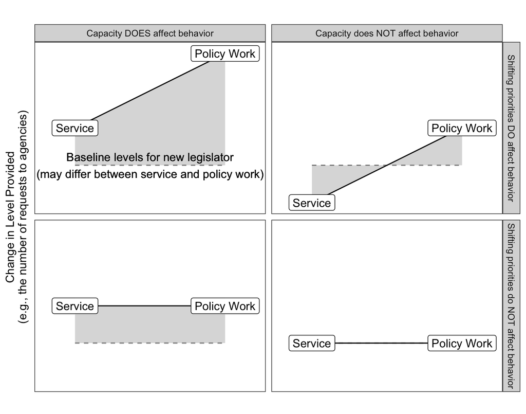

Divergent Predictions for the Change in Levels of Constituency Service and Policy Work as Legislators Gain Experience and Power

```r
library(tidyverse)
x2 <- read_csv(here::here("data", "2x2.csv"))
#
# x2 %>%
#   ggplot() +
#   aes(x = x, y = new, label = lab) +
#   geom_line(aes(y = baseline), linetype = 2, alpha = .5) +
#   geom_line() +
#   geom_ribbon(aes(ymax = new, ymin = baseline), alpha = .2) +
#   facet_wrap("outcome", nrow = 2) +
#   geom_label() +
#   geom_text(aes(label = lab2, y = baseline), check_overlap = T, hjust = 0, vjust = -.2) +
#   labs(y = "Change in Level Provided\n(e.g., the number of requests to agencies)",
#        title = "") +
#   theme_void() +
#   xlim(-.2,1.2) +
#   ylim(-1.1,3.1) +
#   theme(panel.border = element_rect(fill=NA),
#         axis.title.y = element_text(angle = 90))



x2 %>%
  ggplot() +
  aes(x = x, y = new, label = lab) +
  geom_line(aes(y = baseline), linetype = 2, alpha = .5) +
  geom_line() +
  geom_ribbon(aes(ymax = new, ymin = baseline), alpha = .2) +
  facet_grid(priority ~ capacity) +
  geom_label() +
  geom_text(y = 0,
            label = "Baseline levels for new legislator\n(may differ between service and policy work)",
            aes(x = ifelse(capacity == "Capacity DOES affect behavior" & priority == "Shifting priorities DO affect behavior", 0.5, NA))) +
  labs(y = "Change in Level Provided\n(e.g., the number of requests to agencies)",
       title = "",
       x = "") +
  #theme_minimal() +
  xlim(-.2,1.2) +
  ylim(-1.1,3.1) +
  theme(panel.grid = element_blank(),
        panel.border = element_rect(fill=NA),
        axis.text = element_blank(),
        axis.ticks = element_blank(),
        panel.background = element_blank())
```

```r
# x2 %>%
#   ggplot() +
#   aes(x = x, y = new, label = lab) +
#   #geom_point(aes(y = baseline), alpha = .5) +
#   #geom_line() +
#   geom_segment(aes(yend = baseline, xend = x), alpha = .2, size = 20) +
#   facet_wrap("outcome", nrow = 2) +
#   geom_label() +
#   geom_text(aes(label = lab2, y = baseline), check_overlap = T, hjust = 0, vjust = 1.5) +
#   labs(y = "Change in Level Provided\n(e.g., the number of requests to agencies)",
#        title = "") +
#   theme_void() +
#   xlim(-.1,1.1) +
#   ylim(-1.1,3.1) +
#   theme(panel.border = element_rect(fill=NA),
#         axis.title.y = element_text(angle = 90))
```

## 1x2

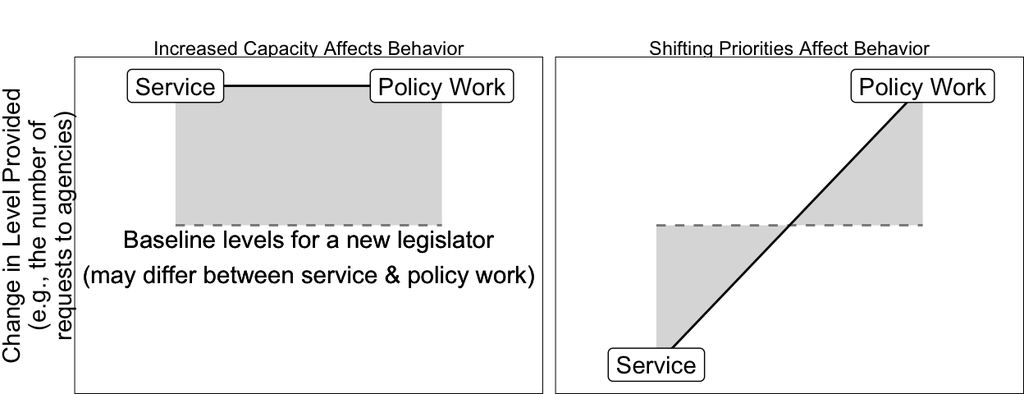

Divergent Predictions for the Change in Levels of Constituency Service and Policy Work as Legislators Gain Experience and Power

```r
# just
x2 %>%
  filter(outcome %in% c("3. Only Increased Capacity Affects Behavior", "2. Only Shifting Priorities Affect Behavior")) %>%
  mutate(outcome = str_remove(outcome, "[1-9].*Only ")) %>%
  ggplot() +
  aes(x = x, y = new, label = lab) +
  geom_line(aes(y = baseline), linetype = 2, alpha = .5) +
  geom_line() +
  geom_ribbon(aes(ymax = new, ymin = baseline), alpha = .2) +
  facet_wrap("outcome", nrow = 1) +
  geom_label() +
  geom_text(y = 0,
            vjust = 1.1,
            label = "Baseline levels for a new legislator\n(may differ between service & policy work)",
            aes(x = ifelse(outcome == "Increased Capacity Affects Behavior", 0.5, NA))) +
  labs(y = "Change in Level Provided\n(e.g., the number of\nrequests to agencies)",
       title = "") +
  theme_void() +
  xlim(-.3,1.3) +
  ylim(-1.1,1.1) +
  theme(panel.border = element_rect(fill=NA),
        axis.title.y = element_text(angle = 90))
```

# Data

```r
read_csv(here("data/_FOIA_response_table.csv")) %>% select(-ends_with("1")) %>% kablebox_long()
```

| Department | Components FOIAed | Records received | Coded | Observations |
| --- | --- | --- | --- | --- |
| Department of Agriculture | 29 | 29 | 11 | 9516 |
| Department of Commerce | 19 | 18 | 10 | 8038 |
| Department of Defense | 49 | 13 | 7 | 9739 |
| Department of Education | 1 | 1 | 1 | 4689 |
| Department of Energy | 8 | 2 | 1 | 6580 |
| Department of Health and Human Services | 15 | 10 | 7 | 104145 |
| Department of Homeland Security | 14 | 13 | 12 | 39633 |
| Department of Housing and Urban Development | 2 | 1 | 1 | 33968 |
| Department of Justice | 23 | 5 | 3 | 2611 |
| Department of Labor | 22 | 12 | 8 | 53341 |
| Department of State | 1 | 0 | 0 | 0 |
| Department of the Interior | 11 | 8 | 6 | 6079 |
| Department of the Treasury | 7 | 5 | 5 | 23869 |
| Department of Transportation | 10 | 7 | 6 | 26787 |
| Department of Veterans Affairs | 6 | 3 | 2 | 77842 |
| Independent Agencies | 77 | 47 | 30 | 81053 |
| Total | 294 | 174 | 110 | 487890 |

```r
# can't cache data

# raw data
load(here::here("data", "all_contacts2.Rdata"))
all_contacts2 <- all_contacts #FIXME

load(here::here("data", "all_contacts_paper.Rdata"))

all_contacts2 %<>% mutate(type = ifelse(TYPE %in% c(1,2,3), "Constituency\nService", NA) ) %>%
  mutate(type = ifelse(TYPE %in% c(4,5), "Policy\nWork", type) )

all_contacts2$Type %<>% str_replace("Indiv. Constituent" , "Constituent (Individual)") %>%
  str_replace("Corp. Constituent" , "Constituent (Corporate)")%>%
  str_replace("501c3 or Local Gov." , "Constituent (501c3 or Local Gov.)")%>%
  str_replace("Corp. Policy" , "Policy (Corporate)")%>%
  str_replace("^Policy$" , "Policy (General)")


load(here::here("data", "dcounts_min.Rdata"))

load(here::here("data", "members.Rdata"))


congress_years2<- function(congress){
        years<- c(congress*2 + 1787, congress*2 + 1788 ) %>% str_c(collapse = ";", sep = ";")
        return(years)
}

# FIXME members data should have years so we don't merge in observations for members in the january (final days of their last term)
# members2 <- members %>%
# mutate(year = congress %>%  congress_years2() %>% str_c(collapse = ";"))

# CAUTION THIS IS WRONG AND WILL PRINT OUT ALL YEARS IN DATA ^2
# members2$year[1]

load(here::here('data', 'agency_vars.Rdata'))

congress_years<- function(congress){
        years<- c(congress*2 + 1787, congress*2 + 1788 )
        return(years)
}

year_congress<- function(year){
    return(floor((year - 1787)/2))
}



d <- dcounts_min %>%
  ungroup() %>%
  mutate(type = ifelse(TYPE %in% c(1,2,3), "Constituency\nService", NA) ) %>%
  mutate(type = ifelse(TYPE %in% c(4,5), "Policy\nWork", type) )

type <- d %>%
  group_by(type) %>%
  summarise(n = sum(per_icpsr_chamber_year_agency_type)) %>%
  ungroup()


type %>%
  rename(type2 = type) %>%
  mutate(percent = n/sum(type$n[1:2])*100) %>% kablebox()
```

| type2 | n | percent |
| --- | --- | --- |
| Constituency Service | 299741 | 80.73723 |
| Policy Work | 71514 | 19.26277 |
| NA | 99832 | 26.89041 |

```r
type5 <- d %>%
  group_by(TYPE) %>%
  summarise(n = sum(per_icpsr_chamber_year_agency_type)) %>%
  ungroup()

type5 %<>%
  mutate(percent = n/sum(type5$n[2:6])*100)

type5 %>% kablebox()
```

| TYPE | n | percent |
| --- | --- | --- |
| 0 | 4787 | 1.2894102 |
| 1 | 240639 | 64.8177129 |
| 2 | 23794 | 6.4090719 |
| 3 | 35308 | 9.5104443 |
| 4 | 13112 | 3.5318043 |
| 5 | 58402 | 15.7309666 |
| 6 | 2416 | 0.6507656 |
| NA | 92629 | 24.9502364 |

```r
type2017 <- d %>%
  filter(year> 2006, year < 2018) %>%
  group_by(type) %>%
  summarise(n = sum(per_icpsr_chamber_year_agency_type)) %>%
  ungroup()

coded <- d %>%
  mutate(coded = !is.na(type)) %>%
  group_by(coded) %>%
  summarise(n = sum(per_icpsr_chamber_year_agency_type))

coded_ratio = coded$n[2]/(sum(coded$n))

multiplier = sum(coded$n)/coded$n[2]

percent <- function(x){
  y <- x*100
  y %<>% round()
  return(y)}
# percent(.434534523453)

d %<>% filter(chamber != "President")

d %<>% mutate(congress = year_congress(year))


members %<>% mutate(member_state = member_state %>%
                     str_replace("\\) ", "-") %>%
                     str_c(")"))

dcounts <- d %>% left_join(members)


type2xchair <- dcounts %>%
  group_by(type, chair) %>%
  summarise(n = sum(per_icpsr_chamber_year_agency_type)) %>%
  ungroup() %>%
  drop_na(type, chair) %>%
  group_by(chair) %>%
  mutate(percent = n / sum(n) *100)

type2xchair%>%
  kablebox()
```

| type | chair | n | percent |
| --- | --- | --- | --- |
| Constituency Service | 0 | 264161 | 81.70214 |
| Constituency Service | 1 | 35230 | 74.22780 |
| Policy Work | 0 | 59161 | 18.29786 |
| Policy Work | 1 | 12232 | 25.77220 |

```r
type2xprestigechair <- dcounts %>%
  group_by(type, prestige_chair) %>%
  summarise(n = sum(per_icpsr_chamber_year_agency_type)) %>%
  ungroup() %>%
  drop_na() %>%
  group_by(prestige_chair) %>%
  mutate(percent = n / sum(n) *100)

type2xprestigechair%>%
  kablebox()
```

| type | prestige_chair | n | percent |
| --- | --- | --- | --- |
| Constituency Service | 0 | 286381 | 80.85725 |
| Constituency Service | 1 | 13010 | 78.35933 |
| Policy Work | 0 | 67800 | 19.14275 |
| Policy Work | 1 | 3593 | 21.64067 |

```r
# prestige committee
type2xprestige <- dcounts %>%
  group_by(type, prestige) %>%
  summarise(n = sum(per_icpsr_chamber_year_agency_type)) %>%
  ungroup() %>%
  drop_na() %>%
  group_by(prestige) %>%
  mutate(percent = n / sum(n) *100)


type2xprestigechair%>%
  kablebox()
```

| type | prestige_chair | n | percent |
| --- | --- | --- | --- |
| Constituency Service | 0 | 286381 | 80.85725 |
| Constituency Service | 1 | 13010 | 78.35933 |
| Policy Work | 0 | 67800 | 19.14275 |
| Policy Work | 1 | 3593 | 21.64067 |

```r
type2xchamber <- dcounts %>%
  group_by(type, chamber) %>%
  summarise(n = sum(per_icpsr_chamber_year_agency_type)) %>%
  ungroup() %>%
  drop_na() %>%
  group_by(chamber) %>%
  mutate(percent = n / sum(n) *100)


# year
type2xyear <- dcounts %>% mutate(years = year  - yearelected) %>%
  group_by(type, years) %>%
  summarise(n = sum(per_icpsr_chamber_year_agency_type)) %>%
  ungroup() %>%
  drop_na() %>%
  group_by(years) %>%
  mutate(percent = n / sum(n) *100)

type2xyear %>%
  kablebox()
```

| type | years | n | percent |
| --- | --- | --- | --- |
| Constituency Service | 1 | 145812 | 79.88954 |
| Constituency Service | 2 | 153567 | 81.57480 |
| Policy Work | 1 | 36705 | 20.11046 |
| Policy Work | 2 | 34686 | 18.42520 |

```r
# chamber averages
dcounts %>%
  group_by(chamber, year, bioname) %>%
  summarise(n = sum(per_icpsr_chamber_year_agency_type)) %>%
  ungroup() %>%
  arrange(-n) %>%
  group_by(chamber) %>%
  summarise(mean_per_year = mean(n) %>% round(0)) %>%
  kablebox()
```

| chamber | mean_per_year |
| --- | --- |
| House | 52 |
| Senate | 156 |

```r
# per member
dcounts %>%
  group_by(bioname, year) %>% summarise(n = sum(per_icpsr_chamber_year_agency_type)) %>%
  ungroup() %>%
  arrange(-n) %>%
  group_by(bioname) %>%
  mutate(mean_per_year = mean(n) %>% round(0)) %>%
  kablebox_long()
```

| bioname | year | n | mean_per_year |
| --- | --- | --- | --- |
| WARNER, Mark | 2014 | 1032 | 453 |
| WEBB, James H. (Jim) | 2010 | 849 | 517 |
| CHAMBLISS, Saxby | 2009 | 800 | 294 |
| McCAIN, John Sidney, III | 2015 | 784 | 380 |
| SCHUMER, Charles Ellis (Chuck) | 2012 | 732 | 486 |
| BYRD, Robert Carlyle | 2009 | 691 | 510 |
| NELSON, Clarence William (Bill) | 2010 | 668 | 455 |
| MIKULSKI, Barbara Ann | 2010 | 657 | 393 |
| SCHUMER, Charles Ellis (Chuck) | 2010 | 650 | 486 |
| GRASSLEY, Charles Ernest | 2010 | 649 | 383 |
| WARNER, Mark | 2015 | 640 | 453 |
| BYRD, Robert Carlyle | 2008 | 621 | 510 |
| McCAIN, John Sidney, III | 2016 | 620 | 380 |
| GILLIBRAND, Kirsten | 2013 | 611 | 332 |
| WEBB, James H. (Jim) | 2009 | 603 | 517 |
| WEBB, James H. (Jim) | 2008 | 599 | 517 |
| NELSON, Clarence William (Bill) | 2009 | 596 | 455 |
| GRASSLEY, Charles Ernest | 2011 | 595 | 383 |
| NELSON, Clarence William (Bill) | 2011 | 580 | 455 |
| GILLIBRAND, Kirsten | 2012 | 572 | 332 |
| DURBIN, Richard Joseph | 2009 | 561 | 272 |
| SCHUMER, Charles Ellis (Chuck) | 2009 | 561 | 486 |
| LUGAR, Richard Green | 2010 | 558 | 410 |
| SCHUMER, Charles Ellis (Chuck) | 2016 | 554 | 486 |
| NELSON, Clarence William (Bill) | 2013 | 553 | 455 |
| LUGAR, Richard Green | 2011 | 541 | 410 |
| MIKULSKI, Barbara Ann | 2013 | 541 | 393 |
| MANCHIN, Joe, III | 2011 | 525 | 260 |
| NELSON, Clarence William (Bill) | 2012 | 522 | 455 |
| MIKULSKI, Barbara Ann | 2011 | 521 | 393 |

[output cut: 70 more lines]

```r
# per member HOUSE
dcounts %>%
  filter(chamber == "House") %>%
  group_by(bioname, year) %>% summarise(n = sum(per_icpsr_chamber_year_agency_type)) %>%
  ungroup() %>%
  arrange(-n) %>%
  group_by(bioname) %>%
  mutate(mean_per_year = mean(n) %>% round(0)) %>%
  kablebox_long()
```

| bioname | year | n | mean_per_year |
| --- | --- | --- | --- |
| WOLF, Frank Rudolph | 2010 | 502 | 377 |
| WOLF, Frank Rudolph | 2009 | 496 | 377 |
| WOLF, Frank Rudolph | 2011 | 480 | 377 |
| WOLF, Frank Rudolph | 2012 | 397 | 377 |
| WOLF, Frank Rudolph | 2008 | 383 | 377 |
| FRANK, Barney | 2010 | 346 | 290 |
| GARRETT, Scott | 2014 | 342 | 145 |
| FRANK, Barney | 2009 | 335 | 290 |
| McCAUL, Michael T. | 2012 | 334 | 202 |
| GARRETT, Scott | 2016 | 333 | 145 |
| COMSTOCK, Barbara J. | 2016 | 332 | 208 |
| McCAUL, Michael T. | 2010 | 329 | 202 |
| SHIMKUS, John M. | 2010 | 326 | 156 |
| FRANK, Barney | 2011 | 323 | 290 |
| SESTAK, Joe | 2010 | 313 | 216 |
| McCAUL, Michael T. | 2009 | 308 | 202 |
| RODRIGUEZ, Ciro D. | 2008 | 306 | 215 |
| DENT, Charles W. | 2010 | 303 | 132 |
| SHIMKUS, John M. | 2009 | 303 | 156 |
| GOODLATTE, Robert William | 2014 | 302 | 172 |
| EDWARDS, Donna F. | 2009 | 295 | 96 |
| CARTWRIGHT, Matt | 2014 | 287 | 139 |
| CARTER, Buddy | 2016 | 284 | 191 |
| RODRIGUEZ, Ciro D. | 2009 | 284 | 215 |
| McCAUL, Michael T. | 2008 | 283 | 202 |
| SHIMKUS, John M. | 2008 | 280 | 156 |
| WOLF, Frank Rudolph | 2013 | 279 | 377 |
| McCAUL, Michael T. | 2011 | 273 | 202 |
| PAUL, Ronald Ernest | 2010 | 268 | 156 |
| FILNER, Bob | 2010 | 264 | 131 |

[output cut: 70 more lines]

```r
dcounts %>%
  group_by(bioname, year) %>% summarise(n = sum(per_icpsr_chamber_year_agency_type)) %>%
  ungroup() %>%
  arrange(n) %>%
  group_by(bioname) %>%
  mutate(mean_per_year = mean(n) %>% round(0)) %>%
  #FIXME
  filter(n > 4) %>%
  kablebox_long()
```

| bioname | year | n | mean_per_year |
| --- | --- | --- | --- |
| AKIN, W. Todd | 2008 | 5 | 16 |
| AMODEI, Mark E. | 2018 | 5 | 14 |
| BARROW, John | 2007 | 5 | 65 |
| BIDEN, Joseph Robinette, Jr. | 2009 | 5 | 27 |
| BISHOP, Robert (Rob) | 2007 | 5 | 29 |
| CROWLEY, Joseph | 2018 | 5 | 33 |
| DAVIS, Danny K. | 2018 | 5 | 25 |
| GARRETT, Thomas Alexander Jr. | 2018 | 5 | 13 |
| HUIZENGA, Bill | 2018 | 5 | 26 |
| JINDAL, Bobby | 2008 | 5 | 22 |
| KENNEDY, Edward Moore (Ted) | 2010 | 5 | 128 |
| KHANNA, Rohit | 2018 | 5 | 10 |
| LAMB, Conor | 2017 | 5 | 6 |
| LEVIN, Sander Martin | 2018 | 5 | 40 |
| LEWIS, John R. | 2018 | 5 | 54 |
| LYNCH, Stephen F. | 2018 | 5 | 26 |
| MARSHALL, Roger Wayne | 2018 | 5 | 10 |
| MULVANEY, Mick | 2017 | 5 | 20 |
| NUNNELEE, Alan | 2015 | 5 | 34 |
| POMEROY, Earl Ralph, III | 2007 | 5 | 23 |
| SALAZAR, Kenneth Lee | 2010 | 5 | 42 |
| SÁNCHEZ, Linda T. | 2018 | 5 | 21 |
| SHULER, Heath | 2007 | 5 | 27 |
| TITUS, Alice (Dina) | 2018 | 5 | 30 |
| TORRES, Norma Judith | 2018 | 5 | 14 |
| VARGAS, Juan | 2018 | 5 | 32 |
| WATERS, Maxine | 2018 | 5 | 23 |
| WELLER, Gerald C. (Jerry) | 2007 | 5 | 8 |
| ABERCROMBIE, Neil | 2010 | 6 | 18 |
| BACHMANN, Michele | 2007 | 6 | 31 |

[output cut: 70 more lines]

## Requests by percentile

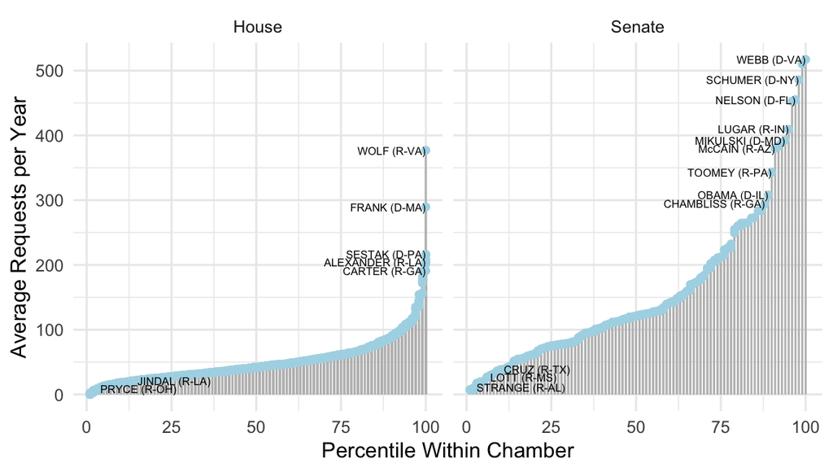

```r
dcounts %>%
    group_by(member_state, chamber, year) %>% summarise(n = sum(per_icpsr_chamber_year_agency_type)) %>%
  group_by(member_state, chamber) %>%
  summarise(mean = mean(n)) %>%
  ungroup() %>%
    group_by(chamber) %>%
  mutate(Percentile = ntile(mean, 100),
         rank = dense_rank(-mean)) %>%
  arrange(-Percentile) %>%
  dplyr::select(member_state, Percentile, mean, chamber,rank) %>% distinct() %>%
    ggplot() +
    geom_col(aes(x = Percentile, y = mean),
             color = "grey",
             width = .000001,
             fill = "black",
             position = "dodge") +
  geom_point(aes(x = Percentile, y = mean), color = "light blue") +
  geom_text(aes(x = Percentile, y = mean, label = ifelse(rank <14 | Percentile < 30, member_state, "")), check_overlap = T, size = 2, hjust = "inward") +
    facet_grid(. ~ chamber , scales = "free_y") + theme_bw() +
  labs(#title = "Average Legislator Requests per Year by Percentile",
       x = "Percentile Within Chamber",
       y = "Average Requests per Year") +
  theme_minimal()
```

## Requests by year

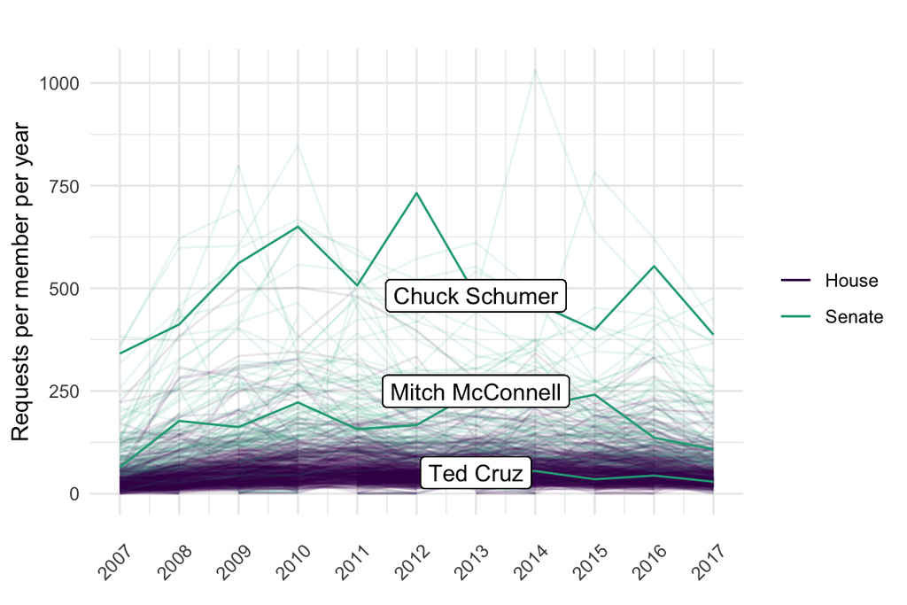

```r
dcounts %<>%
  group_by(bioname, year) %>%
  mutate(per_bioname_year = sum(per_icpsr_chamber_year_agency_type)) %>%
  ungroup() %>%
  group_by(year) %>%
  #mutate(per_bioname_year = per_bioname_year - mean(per_bioname_year)) %>%
  ungroup()

schumer2013 <- dcounts %>% filter(bioname == "SCHUMER, Charles Ellis (Chuck)",
                   year == 2013) %>% .$per_bioname_year %>% unique()

cruz2013 <- dcounts %>% filter(bioname == "CRUZ, Rafael Edward (Ted)",
                   year == 2013) %>% .$per_bioname_year %>% unique()

mcconnell2013 <- dcounts %>% filter(bioname == "McCONNELL, Addison Mitchell (Mitch)",
                   year == 2013) %>% .$per_bioname_year %>% unique()


p <- dcounts %>%
  filter(year > 2006, year <2018) %>%
  distinct(bioname, per_bioname_year, year, chamber) %>%
  ggplot() +
  geom_line(aes(x = year,
                y = per_bioname_year,
                group = bioname,
                color = chamber),
            alpha = .1) +
  geom_line(aes(x = year,
                group = bioname,
                color = chamber,
                y = ifelse(bioname == "SCHUMER, Charles Ellis (Chuck)", per_bioname_year, NA))) +
  geom_label(x = 2013,
             y = schumer2013,
             label = "Chuck Schumer") +
  geom_line(aes(x = year, group = bioname, color = chamber,
                y = ifelse(bioname == "CRUZ, Rafael Edward (Ted)", per_bioname_year, NA))) +
  geom_label(x = 2013,
             y = cruz2013,
             label = "Ted Cruz") +
  geom_line(aes(x = year, group = bioname, color = chamber,
                y = ifelse(bioname == "McCONNELL, Addison Mitchell (Mitch)", per_bioname_year, NA))) +
  geom_label(x = 2013,
             y = mcconnell2013,
             label = "Mitch McConnell") +
  labs(x = "",
       color = " ",
       y = paste("Requests per member per year"),
       title = "") +
  scale_x_continuous(breaks = unique(dcounts$year)) +
  scale_color_viridis_d(begin = 0, end = .6) +
  theme_minimal() +
  theme(panel.background = element_blank(),
        axis.ticks = element_blank(),
        axis.text.x = element_text(angle = 45, vjust = 0))

#FIXME, this takes a long time
p
```

```r
ggsave(here::here("figs/counts-per-year.pdf"), p, height=3, width=7)
```

## Requests by state population

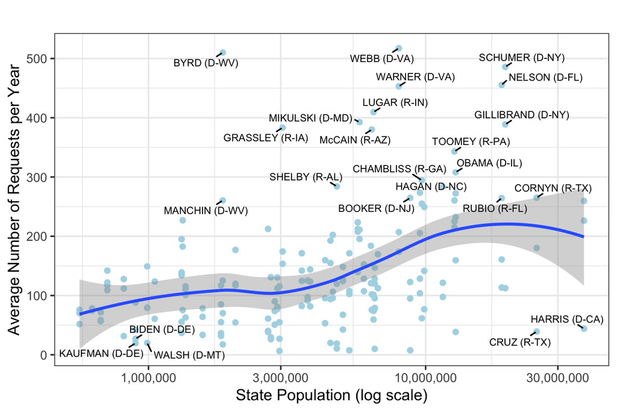

```r
library(scales)


dcounts %>%
  filter(chamber == "Senate") %>%
    group_by(member_state, year, pop2010) %>%
  summarise(n = sum(per_icpsr_chamber_year_agency_type)) %>%
    group_by(member_state, pop2010) %>%
  summarise(mean = mean(n)) %>% ungroup() %>%
    ggplot() +
    geom_point(aes(x = pop2010, y = mean), color = "light blue") +
    geom_smooth(aes(x = pop2010, y = mean)) +
  geom_text_repel(aes(x = pop2010,
                y = mean,
                label = ifelse(mean > 260 |# & log(pop2010) < 17.4 |
                                 mean < 80 & (log(pop2010) > 17 | log(pop2010) <14),
                               member_state,
                               "")),
            seed = 44,
            check_overlap = T,
            min.segment.length = 0,
            size = 2.5) + theme_bw() +
  labs(title = "",
       x = "State Population (log scale)",
       y = "Average Number of Requests per Year") +
  scale_x_log10(labels = comma)
```

## Types of requests

81% of the average legislators’ contacts with agencies are about constituency service.

19% of the average legislators’ contacts with agencies are about policy work.

| type | n |
| --- | --- |
| Constituency Service | 299741 |
| Policy Work | 71514 |
| NA | 99832 |

We classify legislator requests into five overall types:

All data:

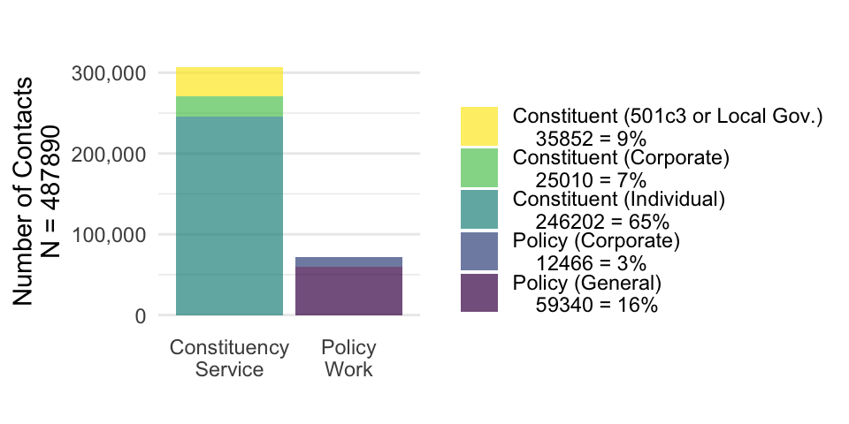

```r
all_contacts2 %>%
  filter(Type != "To be coded") %>%
  mutate(total = n()) %>%
  group_by(Type, total, type) %>%
  summarise(nT = n()) %>%
  mutate(percent = paste0(nT, " = ", 100*round(nT/total, 2), "%"),
         Type = str_c(Type, "\n    ", percent)) %>%
  ungroup() %>%
  #distinct(type, Type, nT)
  ggplot() +
  geom_col(alpha = .7,aes(x = type, fill = Type, y = nT), position ="stack") +
  #coord_flip() +
  scale_y_continuous(labels = scales::comma) +
  labs(x = "",
       fill = "",
       y = paste("Number of Contacts\nN =", sum(nrow(all_contacts2))),
       title = "") +
  #theme_void() +
  theme(panel.border = element_blank(),
        panel.grid.major.x = element_blank(),
        axis.ticks = element_blank(),
        axis.text.x = element_text())
```

Alterntative format:

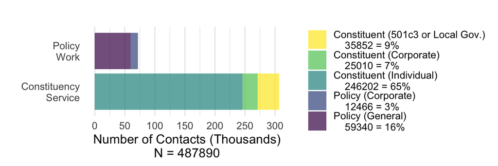

```r
all_contacts2 %>%
  filter(Type != "To be coded") %>%
  mutate(total = n()) %>%
  group_by(Type, total, type) %>%
  summarise(nT = n()) %>%
  mutate(percent = paste0(nT, " = ", 100*round(nT/total, 2), "%"),
         Type = str_c(Type, "\n    ", percent)) %>%
  ungroup() %>%
  #distinct(type, Type, nT)
  ggplot() +
  geom_col(alpha = .7,aes(x = type, fill = Type, y = nT/1000), position ="stack") +
  coord_flip() +
  scale_y_continuous(breaks = seq(0,500, 50)) +
  labs(x = "",
       fill = "",
       y = paste("Number of Contacts (Thousands)\nN =", sum(nrow(all_contacts2))),
       title = "") +
  #theme_void() +
  theme(panel.border = element_blank(),
        panel.grid.major.y = element_blank(),
        axis.ticks = element_blank(),
        axis.text.x.top = element_text())
```

2007-2017 data:

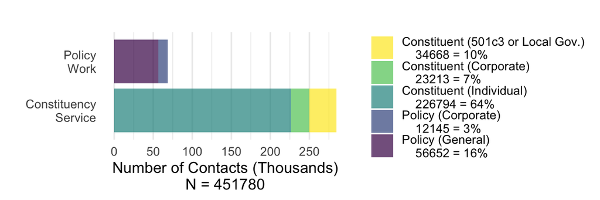

```r
N <- all_contacts2 %>%
  filter(year <2018,
         year > 2006) %>%
  nrow()

all_contacts2 %>%
  filter(Type != "To be coded",
         year <2018,
         year > 2006) %>%
    mutate(total = n()) %>%
  group_by(Type, total, type) %>%
  summarise(nT = n()) %>%
  mutate(percent = paste0(nT, " = ", 100*round(nT/total, 2), "%"),
         Type = str_c(Type, "\n    ", percent)) %>%
  ungroup() %>%
  #distinct(type, Type, nT)
  ggplot() +
  geom_col(alpha = .7,aes(x = type, fill = Type, y = nT/1000), position ="stack") +
  coord_flip() +
  scale_y_continuous(breaks = seq(0,500, 50)) +
  labs(x = "",
       fill = "",
       y = paste("Number of Contacts (Thousands)\nN =", N),
       title = "") +
  #theme_void() +
  theme(panel.border = element_blank(),
        panel.grid.major.y = element_blank(),
        axis.ticks = element_blank(),
        axis.text.x.top = element_text())
```

## Requests by institutional position

The first plot is the contacts we have coded. The second assumes these ratios hold for uncoded letters.

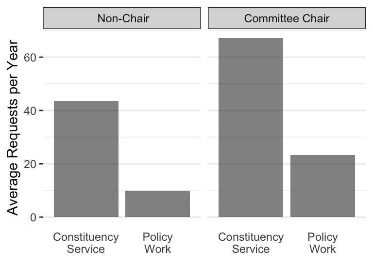

Change in Levels of Constituency Service and Policy Work as Legislators Gain Power

```r
chairs <- all_contacts %>% distinct(icpsr, chair, year)

d %<>% left_join(chairs) %>%
  mutate(chair = chair %>%
           replace_na(0),
         Chair = ifelse(chair == 1, "Committee Chair", " Non-Chair"))

chair <- d %>%
  group_by(type, year, icpsr, Chair) %>%
  summarise(n = sum(per_icpsr_chamber_year_agency_type)) %>%
  group_by(type, Chair) %>%
  summarise(mean = mean(n)) %>%
  ungroup() %>%
  filter(!is.na(type))

chair %>%
  ggplot()  +
  aes(x = type, y = mean) +
  geom_col(alpha = .7,position = "dodge") +
  facet_wrap("Chair") +
  labs(x = "", # "Type of Legislator Request to Agency",
       y = "Average Requests per Year") +
  theme(panel.grid.major.x = element_blank(),
        panel.border = element_blank(),
        axis.ticks.x = element_blank())
```

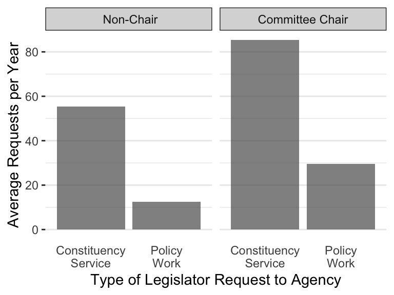

Change in Levels of Constituency Service and Policy Work as Legislators Gain Power

```r
chair %>%
  # assuming consistant proportions to uncoded data
  mutate(mean = mean*multiplier) %>%
  ggplot()  +
  aes(x = type, y = mean) +
  geom_col(alpha = .7,position = "dodge") +
  facet_wrap("Chair") +
  labs(x = "Type of Legislator Request to Agency",
       y = "Average Requests per Year") +
  theme(panel.grid.major.x = element_blank(),
        panel.border = element_blank(),
        axis.ticks.x = element_blank())
```

# Results

## Level

### Member-level

TODO

- members.Rdata going back to most senior member’s first Congress
- what to do with chamber switchers?

```r
#load(here::here('data', 'dcounts_min.Rdata'))

##creating the aggregate count variable
## one obs per agency, member, year
d <- dcounts_min %>%
  group_by(agency, icpsr, chamber, year) %>%
  summarise(perYear = sum(per_icpsr_chamber_year_agency_type))

# dcounts_min %>%
#   mutate(type2 = ifelse(TYPE %in% c(1,2,3), "policy", NA ),
#          type2 = ifelse(TYPE %in% c(4,5), "constituent", type2)) %>%
#   group_by(type2, agency, icpsr, chamber, year) %>%
#   # 2-type counts
#   mutate(perYear_type2 = sum(per_icpsr_chamber_year_agency_type),
#          # versions with NAs for models
#          perYear_con = ifelse(type2 == "constituent", perYear_type2),
#          perYear_pol = ifelse(type2 == "policy", perYear_type2))
#

# constituency service
d_sub <- dcounts_min %>%
  filter(TYPE %in% c(1, 2, 3)) %>%
  group_by(agency, icpsr, chamber, year) %>%
  summarise(perYear_con = sum(per_icpsr_chamber_year_agency_type))

# policy
d_sub2<- dcounts_min %>%
  subset(TYPE %in% c(4, 5)) %>%
  group_by(agency, icpsr, chamber, year) %>%
  summarise(perYear_pol = sum(per_icpsr_chamber_year_agency_type))


d %<>% left_join(d_sub) %>% left_join(d_sub2)

# congress
d$congress <- year_congress(d$year)

d %<>% left_join(members %>%
                 select(congress, icpsr, party,party_code, state_abbrev, district_code, nominate.dim1, presidents_party, female, chair, ranking_minority, party_leader, party_whip, majority, prestige, prestige_chair, yearelected, state), by = c('congress', 'icpsr'))

#FIXME this should all be in members data
# nom <- read_csv(here::here('data', 'nominate_data.csv'))
nom2<- members %>%
  group_by(icpsr) %>%
  summarise(first_cong = min(congress))

nom2$first_year <- 1787 + 2*nom2$first_cong

df<- left_join(d, nom2, by ='icpsr' )
#/FIXME

# Tenure vars
df$tenure<- df$year - df$first_year
df$first<- ifelse(df$tenure==0, 1, 0)
df$second<- ifelse(df$tenure==1, 1, 0)
df$third<- ifelse(df$tenure==2, 1, 0)
df$fourth<- ifelse(df$tenure==3, 1, 0)
df$fifth<- ifelse(df$tenure==4, 1, 0)
df$sixth<- ifelse(df$tenure==5, 1, 0)

# colnames(agency_vars)
df %<>%
  #select(-oversight_committee, -oversight_committee_chair) %>% #FIXME these should be the same
  left_join(agency_vars %>%
                    select(agency, icpsr, chamber, year, oversight_committee,
                           oversight_committee_chair), by = c('agency', 'icpsr', 'year', 'chamber')
            )

df$icpsr_agency<- paste(df$agency, df$icpsr, sep='_')
df$agency_year<- paste(df$agency, df$year, sep='_')

# tenure
df %<>% ungroup() %>%
  group_by(icpsr) %>%
  mutate(max_year = max(tenure))

df$survive <- ifelse((df$chamber=='House' & df$max_year>1)| (df$chamber=='Senate' & df$max_year>5),1, 0 )


##purging repeated values
#FIXME repeats are probably chamber switchers
df %<>%
  add_count(icpsr, year, agency, chamber,
            name = "n")

#FIXME !!!
doubles <- filter(df, n>1) # no doubles (doubles were chamber-switchers)

doubles %>% kablebox()
```

chamber

year

perYear

perYear_con

perYear_pol

congress

party

party_code

state_abbrev

district_code

nominate.dim1

presidents_party

female

chair

ranking_minority

party_leader

party_whip

majority

prestige

prestige_chair

yearelected

state

first_cong

first_year

tenure

first

second

third

fourth

fifth

sixth

oversight_committee

oversight_committee_chair

icpsr_agency

agency_year

max_year

survive

n

Amtrak

14435

House

2013

0

0

0

113

100

MA

0

-0.511

1

0

0

1

0

0

0

1

0

2012

massachusetts

105

1997

16

0

0

0

0

0

0

NA

NA

Amtrak_14435

Amtrak_2013

21

1

2

Amtrak

14435

House

2013

0

0

0

113

100

MA

5

-0.511

1

0

0

1

0

0

0

1

0

2012

massachusetts

105

1997

16

0

0

0

0

0

0

NA

NA

Amtrak_14435

Amtrak_2013

21

1

2

Amtrak

14435

House

2014

0

0

0

113

100

MA

0

-0.511

1

0

0

1

0

0

0

1

0

2012

massachusetts

105

1997

17

0

0

0

0

0

0

NA

NA

Amtrak_14435

Amtrak_2014

21

1

2

Amtrak

14435

House

2014

0

0

0

113

100

MA

5

-0.511

1

0

0

1

0

0

0

1

0

2012

massachusetts

105

1997

17

0

0

0

0

0

0

NA

NA

Amtrak_14435

Amtrak_2014

21

1

2

Amtrak

14435

Senate

2013

0

0

0

113

100

MA

0

-0.511

1

0

0

1

0

0

0

1

0

2012

massachusetts

105

1997

16

0

0

0

0

0

0

NA

NA

Amtrak_14435

Amtrak_2013

21

1

2

Amtrak

14435

Senate

2013

0

0

0

113

100

MA

5

-0.511

1

0

0

1

0

0

0

1

0

2012

massachusetts

105

1997

16

0

0

0

0

0

0

NA

NA

Amtrak_14435

Amtrak_2013

21

1

2

Amtrak

14435

Senate

2014

1

0

0

113

100

MA

0

-0.511

1

0

0

1

0

0

0

1

0

2012

massachusetts

105

1997

17

0

0

0

0

0

0

0

0

Amtrak_14435

Amtrak_2014

21

1

2

Amtrak

14435

Senate

2014

1

0

0

113

100

MA

5

-0.511

1

0

0

1

0

0

0

1

0

2012

massachusetts

105

1997

17

0

0

0

0

0

0

0

0

Amtrak_14435

Amtrak_2014

21

1

2

Amtrak

20115

House

2009

0

0

0

111

200

IL

0

0.274

0

0

0

0

0

0

NA

1

0

NA

illinois

107

2001

8

0

0

0

0

0

0

NA

NA

Amtrak_20115

Amtrak_2009

15

1

2

Amtrak

20115

House

2009

0

0

0

111

200

IL

10

0.274

0

0

0

0

0

0

0

1

0

2008

illinois

107

2001

8

0

0

0

0

0

0

NA

NA

Amtrak_20115

Amtrak_2009

15

1

2

Amtrak

20115

House

2010

1

0

0

111

200

IL

0

0.274

0

0

0

0

0

0

NA

1

0

NA

illinois

107

2001

9

0

0

0

0

0

0

0

0

Amtrak_20115

Amtrak_2010

15

1

2

Amtrak

20115

House

2010

1

0

0

111

200

IL

10

0.274

0

0

0

0

0

0

0

1

0

2008

illinois

107

2001

9

0

0

0

0

0

0

0

0

Amtrak_20115

Amtrak_2010

15

1

2

Amtrak

20115

Senate

2009

0

0

0

111

200

IL

0

0.274

0

0

0

0

0

0

NA

1

0

NA

illinois

107

2001

8

0

0

0

0

0

0

NA

NA

Amtrak_20115

Amtrak_2009

15

1

2

Amtrak

20115

Senate

2009

0

0

0

111

200

IL

10

0.274

0

0

0

0

0

0

0

1

0

2008

illinois

107

2001

8

0

0

0

0

0

0

NA

NA

Amtrak_20115

Amtrak_2009

15

1

2

Amtrak

20115

Senate

2010

0

0

0

111

200

IL

0

0.274

0

0

0

0

0

0

NA

1

0

NA

illinois

107

2001

9

0

0

0

0

0

0

NA

NA

Amtrak_20115

Amtrak_2010

15

1

2

Amtrak

20115

Senate

2010

0

0

0

111

200

IL

10

0.274

0

0

0

0

0

0

0

1

0

2008

illinois

107

2001

9

0

0

0

0

0

0

NA

NA

Amtrak_20115

Amtrak_2010

15

1

2

Amtrak

20730

House

2011

0

0

0

112

200

NV

0

0.463

0

0

0

0

0

0

0

1

0

2010

nevada

110

2007

4

0

0

0

0

1

0

NA

NA

Amtrak_20730

Amtrak_2011

11

1

2

Amtrak

20730

House

2011

0

0

0

112

200

NV

2

0.463

0

0

0

0

0

0

1

1

0

2010

nevada

110

2007

4

0

0

0

0

1

0

NA

NA

Amtrak_20730

Amtrak_2011

11

1

2

Amtrak

20730

House

2012

0

0

0

112

200

NV

0

0.463

0

0

0

0

0

0

0

1

0

2010

nevada

110

2007

5

0

0

0

0

0

1

NA

NA

Amtrak_20730

Amtrak_2012

11

1

2

Amtrak

20730

House

2012

0

0

0

112

200

NV

2

0.463

0

0

0

0

0

0

1

1

0

2010

nevada

110

2007

5

0

0

0

0

0

1

NA

NA

Amtrak_20730

Amtrak_2012

11

1

2

Amtrak

20730

Senate

2011

0

0

0

112

200

NV

0

0.463

0

0

0

0

0

0

0

1

0

2010

nevada

110

2007

4

0

0

0

0

1

0

NA

NA

Amtrak_20730

Amtrak_2011

11

1

2

Amtrak

20730

Senate

2011

0

0

0

112

200

NV

2

0.463

0

0

0

0

0

0

1

1

0

2010

nevada

110

2007

4

0

0

0

0

1

0

NA

NA

Amtrak_20730

Amtrak_2011

11

1

2

Amtrak

20730

Senate

2012

1

0

0

112

200

NV

0

0.463

0

0

0

0

0

0

0

1

0

2010

nevada

110

2007

5

0

0

0

0

0

1

0

0

Amtrak_20730

Amtrak_2012

11

1

2

Amtrak

20730

Senate

2012

1

0

0

112

200

NV

2

0.463

0

0

0

0

0

0

1

1

0

2010

nevada

110

2007

5

0

0

0

0

0

1

0

0

Amtrak_20730

Amtrak_2012

11

1

2

Amtrak

20735

House

2009

1

0

0

111

100

NY

0

-0.474

1

1

0

0

0

0

1

1

0

2008

new york

110

2007

2

0

0

1

0

0

0

0

0

Amtrak_20735

Amtrak_2009

11

1

2

Amtrak

20735

House

2009

1

0

0

111

100

NY

20

-0.474

1

1

0

0

0

0

1

1

0

2008

new york

110

2007

2

0

0

1

0

0

0

0

0

Amtrak_20735

Amtrak_2009

11

1

2

Amtrak

20735

House

2010

0

0

0

111

100

NY

0

-0.474

1

1

0

0

0

0

1

1

0

2008

new york

110

2007

3

0

0

0

1

0

0

NA

NA

Amtrak_20735

Amtrak_2010

11

1

2

Amtrak

20735

House

2010

0

0

0

111

100

NY

20

-0.474

1

1

0

0

0

0

1

1

0

2008

new york

110

2007

3

0

0

0

1

0

0

NA

NA

Amtrak_20735

Amtrak_2010

11

1

2

Amtrak

20735

Senate

2009

0

0

0

111

100

NY

0

-0.474

1

1

0

0

0

0

1

1

0

2008

new york

110

2007

2

0

0

1

0

0

0

NA

NA

Amtrak_20735

Amtrak_2009

11

1

2

Amtrak

20735

Senate

2009

0

0

0

111

100

NY

20

-0.474

1

1

0

0

0

0

1

1

0

2008

new york

110

2007

2

0

0

1

0

0

0

NA

NA

Amtrak_20735

Amtrak_2009

11

1

2

Amtrak

20735

Senate

2010

2

0

0

111

100

NY

0

-0.474

1

1

0

0

0

0

1

1

0

2008

new york

110

2007

3

0

0

0

1

0

0

0

0

Amtrak_20735

Amtrak_2010

11

1

2

Amtrak

20735

Senate

2010

2

0

0

111

100

NY

20

-0.474

1

1

0

0

0

0

1

1

0

2008

new york

110

2007

3

0

0

0

1

0

0

0

0

Amtrak_20735

Amtrak_2010

11

1

2

Amtrak

29534

House

2007

0

0

0

110

200

MS

0

0.376

1

NA

0

0

0

0

0

1

0

2006

mississippi

105

1997

10

0

0

0

0

0

0

NA

NA

Amtrak_29534

Amtrak_2007

21

1

2

Amtrak

29534

House

2007

0

0

0

110

200

MS

1

0.376

1

NA

0

0

0

0

0

1

0

2006

mississippi

105

1997

10

0

0

0

0

0

0

NA

NA

Amtrak_29534

Amtrak_2007

21

1

2

Amtrak

29534

House

2008

0

0

0

110

200

MS

0

0.376

1

NA

0

0

0

0

0

1

0

2006

mississippi

105

1997

11

0

0

0

0

0

0

NA

NA

Amtrak_29534

Amtrak_2008

21

1

2

Amtrak

29534

House

2008

0

0

0

110

200

MS

1

0.376

1

NA

0

0

0

0

0

1

0

2006

mississippi

105

1997

11

0

0

0

0

0

0

NA

NA

Amtrak_29534

Amtrak_2008

21

1

2

Amtrak

29534

Senate

2007

0

0

0

110

200

MS

0

0.376

1

NA

0

0

0

0

0

1

0

2006

mississippi

105

1997

10

0

0

0

0

0

0

NA

NA

Amtrak_29534

Amtrak_2007

21

1

2

Amtrak

29534

Senate

2007

0

0

0

110

200

MS

1

0.376

1

NA

0

0

0

0

0

1

0

2006

mississippi

105

1997

10

0

0

0

0

0

0

NA

NA

Amtrak_29534

Amtrak_2007

21

1

2

Amtrak

29534

Senate

2008

0

0

0

110

200

MS

0

0.376

1

NA

0

0

0

0

0

1

0

2006

mississippi

105

1997

11

0

0

0

0

0

0

NA

NA

Amtrak_29534

Amtrak_2008

21

1

2

Amtrak

29534

Senate

2008

0

0

0

110

200

MS

1

0.376

1

NA

0

0

0

0

0

1

0

2006

mississippi

105

1997

11

0

0

0

0

0

0

NA

NA

Amtrak_29534

Amtrak_2008

21

1

2

CNCS

14435

House

2013

1

0

0

113

100

MA

0

-0.511

1

0

0

1

0

0

0

1

0

2012

massachusetts

105

1997

16

0

0

0

0

0

0

0

0

CNCS_14435

CNCS_2013

21

1

2

CNCS

14435

House

2013

1

0

0

113

100

MA

5

-0.511

1

0

0

1

0

0

0

1

0

2012

massachusetts

105

1997

16

0

0

0

0

0

0

0

0

CNCS_14435

CNCS_2013

21

1

2

CNCS

14435

House

2014

0

0

0

113

100

MA

0

-0.511

1

0

0

1

0

0

0

1

0

2012

massachusetts

105

1997

17

0

0

0

0

0

0

NA

NA

CNCS_14435

CNCS_2014

21

1

2

CNCS

14435

House

2014

0

0

0

113

100

MA

5

-0.511

1

0

0

1

0

0

0

1

0

2012

massachusetts

105

1997

17

0

0

0

0

0

0

NA

NA

CNCS_14435

CNCS_2014

21

1

2

CNCS

14435

Senate

2013

0

0

0

113

100

MA

0

-0.511

1

0

0

1

0

0

0

1

0

2012

massachusetts

105

1997

16

0

0

0

0

0

0

NA

NA

CNCS_14435

CNCS_2013

21

1

2

CNCS

14435

Senate

2013

0

0

0

113

100

MA

5

-0.511

1

0

0

1

0

0

0

1

0

2012

massachusetts

105

1997

16

0

0

0

0

0

0

NA

NA

CNCS_14435

CNCS_2013

21

1

2

CNCS

14435

Senate

2014

0

0

0

113

100

MA

0

-0.511

1

0

0

1

0

0

0

1

0

2012

massachusetts

105

1997

17

0

0

0

0

0

0

NA

NA

CNCS_14435

CNCS_2014

21

1

2

CNCS

14435

Senate

2014

0

0

0

113

100

MA

5

-0.511

1

0

0

1

0

0

0

1

0

2012

massachusetts

105

1997

17

0

0

0

0

0

0

NA

NA

CNCS_14435

CNCS_2014

21

1

2

CNCS

20115

House

2009

0

0

0

111

200

IL

0

0.274

0

0

0

0

0

0

NA

1

0

NA

illinois

107

2001

8

0

0

0

0

0

0

NA

NA

CNCS_20115

CNCS_2009

15

1

2

CNCS

20115

House

2009

0

0

0

111

200

IL

10

0.274

0

0

0

0

0

0

0

1

0

2008

illinois

107

2001

8

0

0

0

0

0

0

NA

NA

CNCS_20115

CNCS_2009

15

1

2

CNCS

20115

House

2010

0

0

0

111

200

IL

0

0.274

0

0

0

0

0

0

NA

1

0

NA

illinois

107

2001

9

0

0

0

0

0

0

NA

NA

CNCS_20115

CNCS_2010

15

1

2

CNCS

20115

House

2010

0

0

0

111

200

IL

10

0.274

0

0

0

0

0

0

0

1

0

2008

illinois

107

2001

9

0

0

0

0

0

0

NA

NA

CNCS_20115

CNCS_2010

15

1

2

CNCS

20115

Senate

2009

0

0

0

111

200

IL

0

0.274

0

0

0

0

0

0

NA

1

0

NA

illinois

107

2001

8

0

0

0

0

0

0

NA

NA

CNCS_20115

CNCS_2009

15

1

2

CNCS

20115

Senate

2009

0

0

0

111

200

IL

10

0.274

0

0

0

0

0

0

0

1

0

2008

illinois

107

2001

8

0

0

0

0

0

0

NA

NA

CNCS_20115

CNCS_2009

15

1

2

CNCS

20115

Senate

2010

0

0

0

111

200

IL

0

0.274

0

0

0

0

0

0

NA

1

0

NA

illinois

107

2001

9

0

0

0

0

0

0

NA

NA

CNCS_20115

CNCS_2010

15

1

2

CNCS

20115

Senate

2010

0

0

0

111

200

IL

10

0.274

0

0

0

0

0

0

0

1

0

2008

illinois

107

2001

9

0

0

0

0

0

0

NA

NA

CNCS_20115

CNCS_2010

15

1

2

CNCS

20730

House

2011

0

0

0

112

200

NV

0

0.463

0

0

0

0

0

0

0

1

0

2010

nevada

110

2007

4

0

0

0

0

1

0

NA

NA

CNCS_20730

CNCS_2011

11

1

2

CNCS

20730

House

2011

0

0

0

112

200

NV

2

0.463

0

0

0

0

0

0

1

1

0

2010

nevada

110

2007

4

0

0

0

0

1

0

NA

NA

CNCS_20730

CNCS_2011

11

1

2

CNCS

20730

House

2012

0

0

0

112

200

NV

0

0.463

0

0

0

0

0

0

0

1

0

2010

nevada

110

2007

5

0

0

0

0

0

1

NA

NA

CNCS_20730

CNCS_2012

11

1

2

CNCS

20730

House

2012

0

0

0

112

200

NV

2

0.463

0

0

0

0

0

0

1

1

0

2010

nevada

110

2007

5

0

0

0

0

0

1

NA

NA

CNCS_20730

CNCS_2012

11

1

2

CNCS

20730

Senate

2011

0

0

0

112

200

NV

0

0.463

0

0

0

0

0

0

0

1

0

2010

nevada

110

2007

4

0

0

0

0

1

0

NA

NA

CNCS_20730

CNCS_2011

11

1

2

CNCS

20730

Senate

2011

0

0

0

112

200

NV

2

0.463

0

0

0

0

0

0

1

1

0

2010

nevada

110

2007

4

0

0

0

0

1

0

NA

NA

CNCS_20730

CNCS_2011

11

1

2

CNCS

20730

Senate

2012

0

0

0

112

200

NV

0

0.463

0

0

0

0

0

0

0

1

0

2010

nevada

110

2007

5

0

0

0

0

0

1

NA

NA

CNCS_20730

CNCS_2012

11

1

2

CNCS

20730

Senate

2012

0

0

0

112

200

NV

2

0.463

0

0

0

0

0

0

1

1

0

2010

nevada

110

2007

5

0

0

0

0

0

1

NA

NA

CNCS_20730

CNCS_2012

11

1

2

CNCS

20735

House

2009

0

0

0

111

100

NY

0

-0.474

1

1

0

0

0

0

1

1

0

2008

new york

110

2007

2

0

0

1

0

0

0

NA

NA

CNCS_20735

CNCS_2009

11

1

2

CNCS

20735

House

2009

0

0

0

111

100

NY

20

-0.474

1

1

0

0

0

0

1

1

0

2008

new york

110

2007

2

0

0

1

0

0

0

NA

NA

CNCS_20735

CNCS_2009

11

1

2

CNCS

20735

House

2010

0

0

0

111

100

NY

0

-0.474

1

1

0

0

0

0

1

1

0

2008

new york

110

2007

3

0

0

0

1

0

0

NA

NA

CNCS_20735

CNCS_2010

11

1

2

CNCS

20735

House

2010

0

0

0

111

100

NY

20

-0.474

1

1

0

0

0

0

1

1

0

2008

new york

110

2007

3

0

0

0

1

0

0

NA

NA

CNCS_20735

CNCS_2010

11

1

2

CNCS

20735

Senate

2009

0

0

0

111

100

NY

0

-0.474

1

1

0

0

0

0

1

1

0

2008

new york

110

2007

2

0

0

1

0

0

0

NA

NA

CNCS_20735

CNCS_2009

11

1

2

CNCS

20735

Senate

2009

0

0

0

111

100

NY

20

-0.474

1

1

0

0

0

0

1

1

0

2008

new york

110

2007

2

0

0

1

0

0

0

NA

NA

CNCS_20735

CNCS_2009

11

1

2

CNCS

20735

Senate

2010

4

0

0

111

100

NY

0

-0.474

1

1

0

0

0

0

1

1

0

2008

new york

110

2007

3

0

0

0

1

0

0

0

0

CNCS_20735

CNCS_2010

11

1

2

CNCS

20735

Senate

2010

4

0

0

111

100

NY

20

-0.474

1

1

0

0

0

0

1

1

0

2008

new york

110

2007

3

0

0

0

1

0

0

0

0

CNCS_20735

CNCS_2010

11

1

2

CSOSA

14435

House

2013

0

0

0

113

100

MA

0

-0.511

1

0

0

1

0

0

0

1

0

2012

massachusetts

105

1997

16

0

0

0

0

0

0

NA

NA

CSOSA_14435

CSOSA_2013

21

1

2

CSOSA

14435

House

2013

0

0

0

113

100

MA

5

-0.511

1

0

0

1

0

0

0

1

0

2012

massachusetts

105

1997

16

0

0

0

0

0

0

NA

NA

CSOSA_14435

CSOSA_2013

21

1

2

CSOSA

14435

House

2014

0

0

0

113

100

MA

0

-0.511

1

0

0

1

0

0

0

1

0

2012

massachusetts

105

1997

17

0

0

0

0

0

0

NA

NA

CSOSA_14435

CSOSA_2014

21

1

2

CSOSA

14435

House

2014

0

0

0

113

100

MA

5

-0.511

1

0

0

1

0

0

0

1

0

2012

massachusetts

105

1997

17

0

0

0

0

0

0

NA

NA

CSOSA_14435

CSOSA_2014

21

1

2

CSOSA

14435

Senate

2013

0

0

0

113

100

MA

0

-0.511

1

0

0

1

0

0

0

1

0

2012

massachusetts

105

1997

16

0

0

0

0

0

0

NA

NA

CSOSA_14435

CSOSA_2013

21

1

2

CSOSA

14435

Senate

2013

0

0

0

113

100

MA

5

-0.511

1

0

0

1

0

0

0

1

0

2012

massachusetts

105

1997

16

0

0

0

0

0

0

NA

NA

CSOSA_14435

CSOSA_2013

21

1

2

CSOSA

14435

Senate

2014

0

0

0

113

100

MA

0

-0.511

1

0

0

1

0

0

0

1

0

2012

massachusetts

105

1997

17

0

0

0

0

0

0

NA

NA

CSOSA_14435

CSOSA_2014

21

1

2

CSOSA

14435

Senate

2014

0

0

0

113

100

MA

5

-0.511

1

0

0

1

0

0

0

1

0

2012

massachusetts

105

1997

17

0

0

0

0

0

0

NA

NA

CSOSA_14435

CSOSA_2014

21

1

2

CSOSA

20730

House

2011

0

0

0

112

200

NV

0

0.463

0

0

0

0

0

0

0

1

0

2010

nevada

110

2007

4

0

0

0

0

1

0

NA

NA

CSOSA_20730

CSOSA_2011

11

1

2

CSOSA

20730

House

2011

0

0

0

112

200

NV

2

0.463

0

0

0

0

0

0

1

1

0

2010

nevada

110

2007

4

0

0

0

0

1

0

NA

NA

CSOSA_20730

CSOSA_2011

11

1

2

CSOSA

20730

House

2012

0

0

0

112

200

NV

0

0.463

0

0

0

0

0

0

0

1

0

2010

nevada

110

2007

5

0

0

0

0

0

1

NA

NA

CSOSA_20730

CSOSA_2012

11

1

2

CSOSA

20730

House

2012

0

0

0

112

200

NV

2

0.463

0

0

0

0

0

0

1

1

0

2010

nevada

110

2007

5

0

0

0

0

0

1

NA

NA

CSOSA_20730

CSOSA_2012

11

1

2

CSOSA

20730

Senate

2011

0

0

0

112

200

NV

0

0.463

0

0

0

0

0

0

0

1

0

2010

nevada

110

2007

4

0

0

0

0

1

0

NA

NA

CSOSA_20730

CSOSA_2011

11

1

2

CSOSA

20730

Senate

2011

0

0

0

112

200

NV

2

0.463

0

0

0

0

0

0

1

1

0

2010

nevada

110

2007

4

0

0

0

0

1

0

NA

NA

CSOSA_20730

CSOSA_2011

11

1

2

CSOSA

20730

Senate

2012

0

0

0

112

200

NV

0

0.463

0

0

0

0

0

0

0

1

0

2010

nevada

110

2007

5

0

0

0

0

0

1

NA

NA

CSOSA_20730

CSOSA_2012

11

1

2

CSOSA

20730

Senate

2012

0

0

0

112

200

NV

2

0.463

0

0

0

0

0

0

1

1

0

2010

nevada

110

2007

5

0

0

0

0

0

1

NA

NA

CSOSA_20730

CSOSA_2012

11

1

2

CSOSA

29534

House

2008

0

0

0

110

200

MS

0

0.376

1

NA

0

0

0

0

0

1

0

2006

mississippi

105

1997

11

0

0

0

0

0

0

NA

NA

CSOSA_29534

CSOSA_2008

21

1

2

CSOSA

29534

House

2008

0

0

0

110

200

MS

1

0.376

1

NA

0

0

0

0

0

1

0

2006

mississippi

105

1997

11

0

0

0

0

0

0

NA

NA

CSOSA_29534

CSOSA_2008

21

1

2

CSOSA

29534

Senate

2008

0

0

0

110

200

MS

0

0.376

1

NA

0

0

0

0

0

1

0

2006

mississippi

105

1997

11

0

0

0

0

0

0

NA

NA

CSOSA_29534

CSOSA_2008

21

1

2

CSOSA

29534

Senate

2008

0

0

0

110

200

MS

1

0.376

1

NA

0

0

0

0

0

1

0

2006

mississippi

105

1997

11

0

0

0

0

0

0

NA

NA

CSOSA_29534

CSOSA_2008

21

1

2

DHHS_ACF

14435

House

2013

0

0

0

113

100

MA

0

-0.511

1

0

0

1

0

0

0

1

0

2012

massachusetts

105

1997

16

0

0

0

0

0

0

NA

NA

DHHS_ACF_14435

DHHS_ACF_2013

21

1

2

DHHS_ACF

14435

House

2013

0

0

0

113

100

MA

5

-0.511

1

0

0

1

0

0

0

1

0

2012

massachusetts

105

1997

16

0

0

0

0

0

0

NA

NA

DHHS_ACF_14435

DHHS_ACF_2013

21

1

2

DHHS_ACF

14435

House

2014

0

0

0

113

100

MA

0

-0.511

1

0

0

1

0

0

0

1

0

2012

massachusetts

105

1997

17

0

0

0

0

0

0

NA

NA

DHHS_ACF_14435

DHHS_ACF_2014

21

1

2

DHHS_ACF

14435

House

2014

0

0

0

113

100

MA

5

-0.511

1

0

0

1

0

0

0

1

0

2012

massachusetts

105

1997

17

0

0

0

0

0

0

NA

NA

DHHS_ACF_14435

DHHS_ACF_2014

21

1

2

DHHS_ACF

14435

Senate

2013

0

0

0

113

100

MA

0

-0.511

1

0

0

1

0

0

0

1

0

2012

massachusetts

105

1997

16

0

0

0

0

0

0

NA

NA

DHHS_ACF_14435

DHHS_ACF_2013

21

1

2

DHHS_ACF

14435

Senate

2013

0

0

0

113

100

MA

5

-0.511

1

0

0

1

0

0

0

1

0

2012

massachusetts

105

1997

16

0

0

0

0

0

0

NA

NA

DHHS_ACF_14435

DHHS_ACF_2013

21

1

2

DHHS_ACF

14435

Senate

2014

1

0

1

113

100

MA

0

-0.511

1

0

0

1

0

0

0

1

0

2012

massachusetts

105

1997

17

0

0

0

0

0

0

0

0

DHHS_ACF_14435

DHHS_ACF_2014

21

1

2

DHHS_ACF

14435

Senate

2014

1

0

1

113

100

MA

5

-0.511

1

0

0

1

0

0

0

1

0

2012

massachusetts

105

1997

17

0

0

0

0

0

0

0

0

DHHS_ACF_14435

DHHS_ACF_2014

21

1

2

```r
# drop doubles
df %<>% filter(n<2)


# LEVEL MODELS

df %<>%
  # mutate(agency_year) %>%
  mutate(lpyear = log(perYear + 1))
```

### District-level

- Were most maps in place by 2011?

```r
####
# Redistricting? were most maps in place by 2011?
decade<- case_when(df$year < 2011 ~ '0',
                   df$year > 2010 ~ '1')

state_dist<- case_when(df$chamber=='Senate'~ paste(df$state,
                                                    df$district_code,
                                                    sep='_' ),
                       df$chamber =='House'~ paste(paste(df$state,
                                                          df$district_code,
                                                          sep='_'),
                                                    decade,
                                                    sep='_'))




df$state_dist<- state_dist

perDist<- df %>%
  group_by(year, state_dist, icpsr, chamber, tenure, state) %>%
  summarise(perYear = sum(perYear)) %>%
  distinct()



## Now, we want to identify when there is a new member in a district.  To do this, we look for changes in the icpsr number
perDist$new_member<- ifelse(perDist$tenure==0, 1, 0)

perDist$second_year<- ifelse(perDist$tenure==1, 1, 0)
perDist$third_year<- ifelse(perDist$tenure==2, 1, 0)
perDist$fourth_year<- ifelse(perDist$tenure==3, 1, 0)
perDist$fifth_year<- ifelse(perDist$tenure==4, 1, 0)
perDist$sixth_year<- ifelse(perDist$tenure==5, 1, 0)


state_level<- perDist %>% group_by(state, year) %>%
  summarise(numpers = n(),
            sumYear = sum(perYear),
            mean_new = mean(new_member))

state_new <- ifelse(state_level$mean_new>0, 1, 0)

state_level$state_new <- state_new

perDist %<>% left_join(state_level %>%
                         select(state_new, mean_new, state, year),
                    by = c('state', 'year'))
#########################
# saved as DistrictLevel
########################
# save(perDist, file =  here::here("data", "perDist.Rdata"))
############################################
```

## Priority

```r
##creating the ratio variable
d_rat <- df %>%
  group_by(year, icpsr, chamber,
           prestige, prestige_chair, chair, ranking_minority, majority, presidents_party,
           first, second, third, fourth, fifth, sixth) %>%
  # per member per year counts per type2
  summarise(perCon = sum(perYear_con),
            perPol = sum(perYear_pol)) %>%
  # ratio of con to pol
  #FIXME switch?
  mutate(ratio = perCon/(perCon + perPol))

# drop doubles
d_rat %<>% group_by(year, icpsr, chamber) %>% add_count(name = "n")

doubles_ratio <- filter(d_rat, n>1)

doubles_ratio %>% kablebox()
```

| year | icpsr | chamber | prestige | prestige_chair | chair | ranking_minority | majority | presidents_party | first | second | third | fourth | fifth | sixth | perCon | perPol | ratio | n |
| --- | --- | --- | --- | --- | --- | --- | --- | --- | --- | --- | --- | --- | --- | --- | --- | --- | --- | --- |

```r
d_rat %<>% filter(n<2)

############################################
# d_rat saved as ProportionContact.dta')
# save(d_rat, file =  here::here("data", "d_rat.Rdata"))
############################################

# RATIO MODEL
```

## Joint Effect of Capacity and Priority

```r
r = .2

r2 = .31

z = 100

x = z*r
y = z-z*r


z2 = 120

x2 = z2*r2
y2 = z2-z2*r2
```

Combining model estimates for the shift in the level of requests and relative priority of policy work to constituency service, we see that even as the ratio of policy work increases, constituency service also significantly increases.

These estimates are calculated by adding diff-in-diff regression coefficients for committee chairs’ increased levels of requests to the baseline levels for non-chairs. We also adjust the ratio of policy work to constituency service based on the diff-in-diff regression coefficients for committee chairs’ increased policy work ratio.

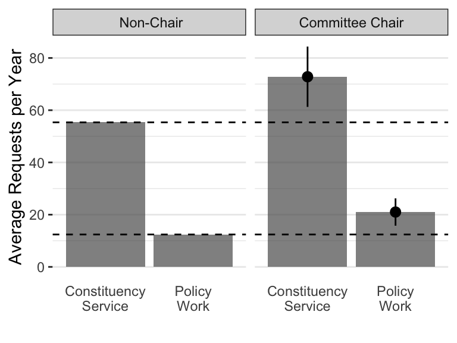

Difference-in-Difference Estimates of Change in Levels of Constituency Service and Policy Work as Legislators Gain Power

```r
n_agencies <- dcounts_min$agency %>% unique() %>% length()

#FIXME replace with tidy model output
# TABLE 1
level <- tribble(~term, ~estimate, ~std.error,
                 "chair", 0.206, 0.0951)

# per member across all agencies
level$estimate <- level$estimate*n_agencies
level$std.error <- level$std.error*n_agencies

# ratio of policy work for non-chairs
base_ratio <- chair$mean[3]/chair$mean[1]

# level estimates with baseline ratio (for presenting level effects only)
level_con <- level %>% mutate(estimate = estimate*(1-base_ratio),
                               std.error = std.error*(1-base_ratio))

level_pol <- level %>% mutate(estimate = estimate*(base_ratio),
                               std.error = std.error*(base_ratio))


# Priority Table
priority <- tribble(~term, ~estimate, ~std.error,
                 "chair", 0.0875, 0.0175)

# adjust level estimates with new ratio (joint effects )
new_ratio <- base_ratio + priority$estimate[1]

level_con <- level %>% mutate(estimate = estimate*(1-new_ratio),
                               std.error = std.error*(1-new_ratio))

level_pol <- level %>% mutate(estimate = estimate*(new_ratio),
                               std.error = std.error*(new_ratio))


#FIXME, include priority model uncertianty too
chair$std.error <- NA
# constituent error
chair$std.error[2] <- level_con$std.error[1]
# policy error
chair$std.error[4] <- level_pol$std.error[1]


# chair mean = non-chair mean * level coef
# constituent estimate
chair$mean[2] <- chair$mean[1] + (1 + level_con$estimate[1] )
# policy estimate
chair$mean[4] <- chair$mean[3] + (1+level_pol$estimate[1] )

chair_adjusted <- chair %>%
  # assuming consistant proportions to uncoded data
  mutate(mean = mean*multiplier) %>%
  # baseline = non-chairs mean
  mutate(baseline = ifelse(Chair == "Committee Chair", NA, mean) ) %>%
  fill(baseline) %>%
  # point estimates and uncertiatty only for chair estimates
  mutate(estimate = ifelse(Chair == "Committee Chair", mean, NA)) %>%
  mutate(std.error = ifelse(Chair == "Committee Chair", std.error, NA))

chair_adjusted %>%
  #mutate(Chair = ifelse() )
  ggplot()  +
  aes(x = type, y = mean) +
  geom_col(alpha = .7, position = "dodge") +
  geom_hline(aes(yintercept = baseline), linetype = 2) +
  geom_pointrange(aes(y = estimate,
                      ymin = mean-1.96*std.error,
                      ymax = mean+1.96*std.error)) +
  facet_wrap("Chair") +
  labs(x = "", #Type of Legislator Request to Agency",
       y = "Average Requests per Year") +
  theme(panel.grid.major.x = element_blank(),
        panel.border = element_blank(),
        axis.ticks.x = element_blank())
```

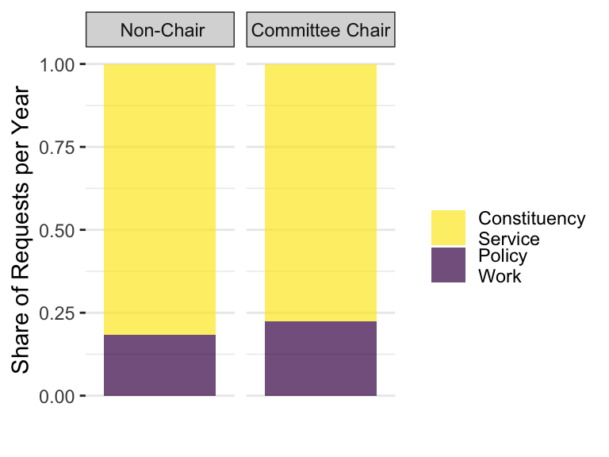

Difference-in-Difference Estimates of Change in Levels of Constituency Service and Policy Work as Legislators Gain Power

```r
chair_adjusted %<>% mutate(baseline = ifelse(type =="Constituency\nService", baseline+ 12.4, baseline))


# stacked to show ratio with PERCENTS
chair_adjusted %>%
  #mutate(Chair = ifelse() )
  ggplot()  +
  aes(x = Chair, y = mean, fill = type) +
  geom_col(alpha = .7, position = "fill") +
  facet_wrap("Chair", scales = "free_x") +
  labs(x = "", #Type of Legislator Request to Agency",
       y = "Share of Requests per Year",
       fill = "") +
  theme(panel.grid.major.x = element_blank(),
        axis.text.x = element_blank(),
        panel.border = element_blank(),
        axis.ticks.x = element_blank())
```

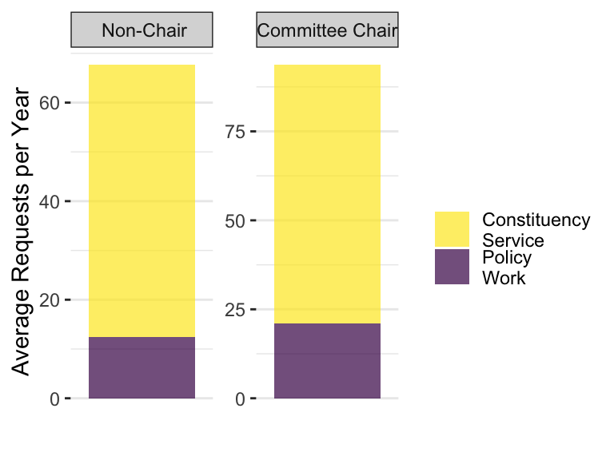

Difference-in-Difference Estimates of Change in Levels of Constituency Service and Policy Work as Legislators Gain Power

```r
# stacked to show ratio + free scales
chair_adjusted %>%
  #mutate(Chair = ifelse() )
  ggplot()  +
  aes(x = Chair, y = mean, fill = type) +
  geom_col(alpha = .7, position = "stack") +
  #geom_hline(aes(yintercept = baseline), linetype = 2) +
  #geom_pointrange(aes(y = estimate,
                      #ymin = mean-1.96*std.error,
                      #ymax = mean+1.96*std.error)) +
  facet_wrap("Chair", scales = "free") +
  #scale_y_
  labs(x = "", #Type of Legislator Request to Agency",
       y = "Average Requests per Year",
       fill = "") +
  theme(panel.grid.major.x = element_blank(),
        axis.text.x = element_blank(),
        panel.border = element_blank(),
        axis.ticks.x = element_blank())
```

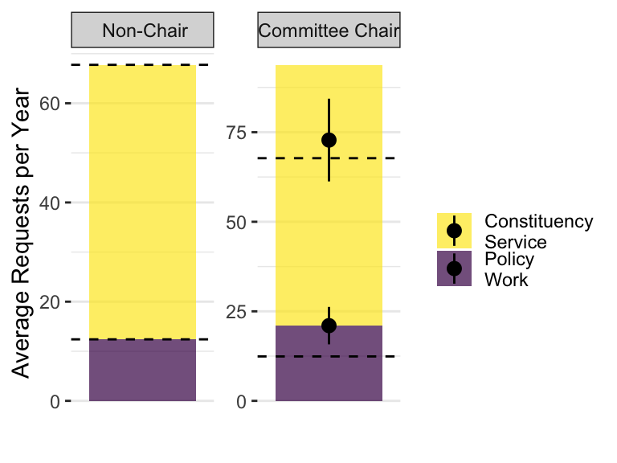

Difference-in-Difference Estimates of Change in Levels of Constituency Service and Policy Work as Legislators Gain Power

```r
# stacked to show ratio + CI
chair_adjusted %>%
  #mutate(Chair = ifelse() )
  ggplot()  +
  aes(x = Chair, y = mean, fill = type) +
  geom_col(alpha = .7, position = "stack") +
  geom_hline(aes(yintercept = baseline), linetype = 2) +
  geom_pointrange(aes(y = estimate,
                      ymin = mean-1.96*std.error,
                      ymax = mean+1.96*std.error)) +
  facet_wrap("Chair", scales = "free") +
  labs(x = "", #Type of Legislator Request to Agency",
       y = "Average Requests per Year",
       fill = "") +
  theme(panel.grid.major.x = element_blank(),
        axis.text.x = element_blank(),
        panel.border = element_blank(),
        axis.ticks.x = element_blank())
```

The baseline level (non-chairs) is 55.3494555 constituency service requests and 12.404877 policy requests per year.

The baseline ratio (for non-chairs) of policy work to constituency service is 0.2241192. Adding the model coefficient from the difference in difference model of shifting priorities yields a new ratio of 0.3116192.

The model-estimated level for committee chairs is 72.8128495 constituency service requests and 21.0047737 policy requests per year.

#TODO

- intercoder agrement for USTR
- y-axis label and remove the title from inequality figure
- facet distribution across types by policy and constituent, probably coord flip as well
- [ x ] remove the title from state pop figure